# KNN

# 1 References[^1]

- SMDA2, Lecture XXX
- SML, Lecture 4

# 2 Example from SMDA2 Lecture 2: Curse of Dimensionality

We want to study the distance between a target point and it’s nearest neighbor as the dimension increases.

##### We first we study p=1 dimension

```r
set.seed(1)
```

Generate 10 x_i uniformly on [−1, 1]

```r
p <- 1
n <- 10
x <- runif(n, -1, 1)
```

The True noiseless relationship is $y = e^{-8||x||^2}$

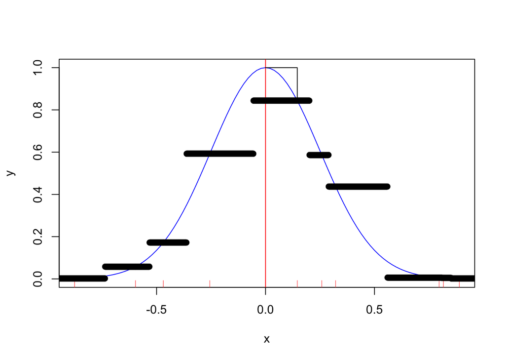

```r
y <- exp(-8*x^2)
plot(x, y, ylim = c(0,1), pch = 19, col = "red")
abline(v = 0, col = "red")
curve(exp(-8*x^2), from = -1, to = 1, col = "blue", add = TRUE)
rug(x, col = "red")

#Calculate the nearest neighbor to target 0
hat_y <- y[which.min(abs(x))]
min_x <- x[which.min(abs(x))]

lines(c(min_x, min_x), c(hat_y, 1))
lines(c(0, min_x), c(1, 1))

# Let's give the kNN estimate for k=1

x_seq    <- seq(-1, 1, by = .001)
seq_mat  <- matrix(rep(x_seq, each = length(x)), ncol = length(x), byrow = TRUE)
x_mat    <- matrix(rep(x, each = length(x_seq)), nrow = length(x_seq))
dist_mat <- (seq_mat - x_mat)^2
y_seq    <- y[apply(dist_mat, 1, which.min)]
points(x_seq, y_seq)
```

##### Next we study p=2 dimension2

Generate 10 x_i uniformly on [−1, 1]^2

```r
p <- 2
n <- 10
x <- matrix(runif(n*p, -1, 1), nrow = n, ncol = p)
```

The True noiseless relationship is $y = e^{-8||x||^2}$

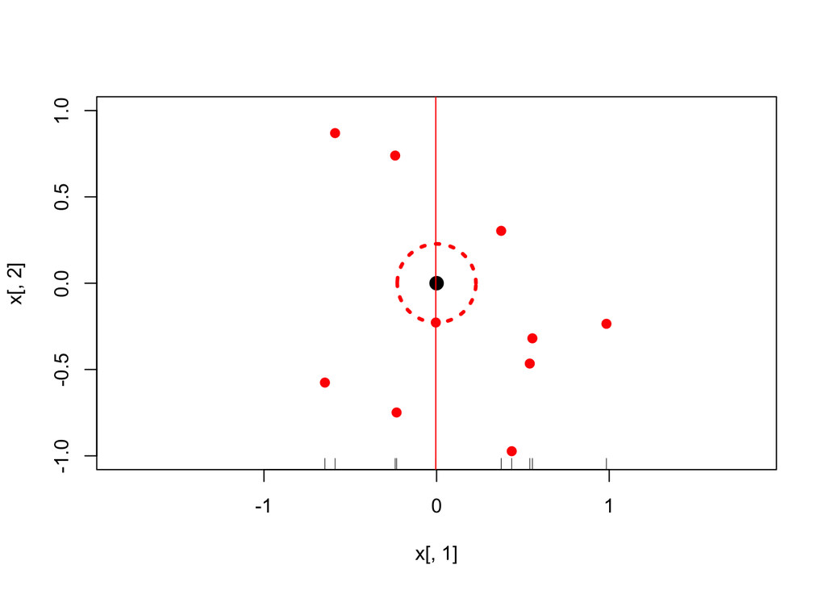

```r
nrm_x <- apply(x^2, 1, sum)
y     <- exp(-8*nrm_x^2)
plot(x[, 1], x[, 2], xlim = c(-1,1), ylim = c(-1,1), asp = 1, pch = 19, col = "red")
points(0, 0, pch = 19, cex = 1.5)



# Calculate the nearest neighbor to target (0,0)


hat_y <- y[which.min(nrm_x)]
min_x <- x[which.min(nrm_x), ]
dist_2 <- sqrt(nrm_x[which.min(nrm_x)])

radius <- dist_2
theta  <- seq(0, 2 * pi, length = 200)
lines(x = radius * cos(theta), y = radius * sin(theta), col = "red", lty = 3, lwd = 3)

# Consider projecting the data onto the first dimension, the nearest neighbor is much closer

rug(x[, 1])
one_dim_min_x <- x[which.min(abs(x))]
abline(v = one_dim_min_x, col = "red")
```

```r
dist_1 <- abs(one_dim_min_x)
```

# 3 Let’s calculate 1000 simulations in each of 1 and 2 dimensions when n = 10

```r
sims <- 1000
dist_1 <- rep(NA, sims)
dist_2 <- rep(NA, sims)

p1 <- 1
p2 <- 2
n  <- 10

for (i in 1:sims) {
  x1 <- matrix(runif(n*p1, -1, 1), nrow = n, ncol = p1)
  x2 <- matrix(runif(n*p2, -1, 1), nrow = n, ncol = p2)

  nrm_x1 <- apply(x1^2, 1, sum)
  nrm_x2 <- apply(x2^2, 1, sum)

  dist_1[i] <- sqrt(nrm_x1[which.min(nrm_x1)])
  dist_2[i] <- sqrt(nrm_x2[which.min(nrm_x2)])
}

mean(dist_1)
```

```
## [1] 0.08862825
```

```r
mean(dist_2)
```

```
## [1] 0.309566
```

# 4 Let’s calculate 1000 simulations in each of 1 and 2 dimensions when n = 1000

```r
sims <- 1000
dist_1 <- rep(NA, sims)
dist_2 <- rep(NA, sims)

p1 <- 1
p2 <- 2
n  <- 1000

for (i in 1:sims) {
  x1 <- matrix(runif(n*p1, -1, 1), nrow = n, ncol = p1)
  x2 <- matrix(runif(n*p2, -1, 1), nrow = n, ncol = p2)

  nrm_x1 <- apply(x1^2, 1, sum)
  nrm_x2 <- apply(x2^2, 1, sum)

  dist_1[i] <- sqrt(nrm_x1[which.min(nrm_x1)])
  dist_2[i] <- sqrt(nrm_x2[which.min(nrm_x2)])
}

mean(dist_1)
```

```
## [1] 0.0009956784
```

```r
mean(dist_2)
```

```
## [1] 0.03176299
```

##### Let’s calculate 1000 simulations in dimensions 1 through 10 for n = 1000

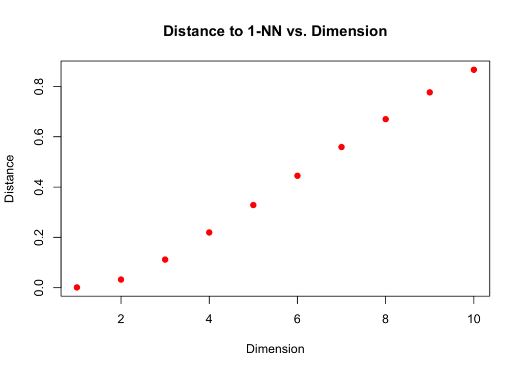

```r
sims <- 1000
p    <- seq(1, 10)
n    <- 1000

dist_mat <- matrix(NA, nrow = sims, ncol = length(p))
colnames(dist_mat) <- p

for (i in 1:sims) {
  for (dim in p) {
    x     <- matrix(runif(n*dim, -1, 1), nrow = n, ncol = dim)
    nrm_x <- apply(x^2, 1, sum)

    dist_mat[i, dim] <- sqrt(nrm_x[which.min(nrm_x)])
  }
}

distances <- apply(dist_mat, 2, mean)

plot(p, distances, pch = 19, col = "red", main = "Distance to 1-NN vs. Dimension", xlab = "Dimension", ylab = "Distance")
```

# 5 Example from SML Lecture 4: KNN Classification

```r
library(ISLR)
head(Smarket, 3)
```

```
##   Year  Lag1   Lag2   Lag3   Lag4   Lag5 Volume  Today Direction
## 1 2001 0.381 -0.192 -2.624 -1.055  5.010 1.1913  0.959        Up
## 2 2001 0.959  0.381 -0.192 -2.624 -1.055 1.2965  1.032        Up
## 3 2001 1.032  0.959  0.381 -0.192 -2.624 1.4112 -0.623      Down
```

Explore the data

```r
mean(Smarket$Lag1[Smarket$Direction == "Up"])
```

```
## [1] -0.03969136
```

```r
mean(Smarket$Lag1[Smarket$Direction == "Down"])
```

```
## [1] 0.05068605
```

Plot

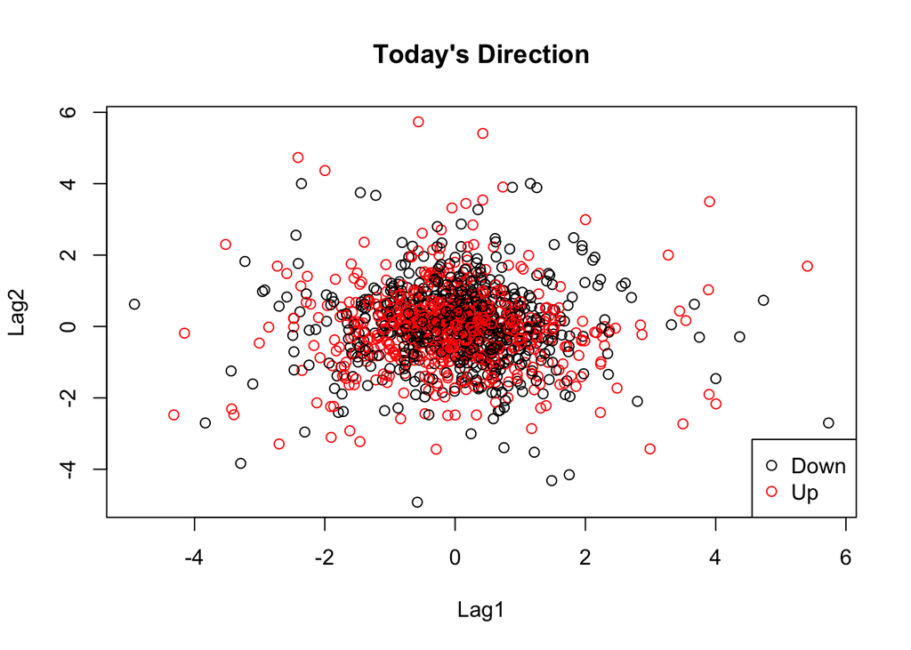

```r
plot(Smarket$Lag1, Smarket$Lag2, col = Smarket$Direction,
     xlab="Lag1", ylab="Lag2", main="Today's Direction")
legend("bottomright", legend = levels(Smarket$Direction),
       col=1:length(levels(Smarket$Direction)), pch=1)
```

Coding example (K = 5 and new point (2, 4.25))

```r
K           <- 5
Lag1.new    <- 2
Lag2.new    <- 4.25

dists       <- sqrt((Smarket$Lag1 - Lag1.new)^2+ (Smarket$Lag2 - Lag2.new)^2)

neighbors  <- order(dists)[1:K]
neighb.dir <- Smarket$Direction[neighbors]
choice     <- names(which.max(table(neighb.dir)))
choice
```

```
## [1] "Down"
```

##### kNN function

```r
KNN.decision <- function(Lag1.new, Lag2.new, K = 5,
                         Lag1 = Smarket$Lag1,
                         Lag2 = Smarket$Lag2,
                         Dir = Smarket$Direction) {
  n <- length(Lag1)
  stopifnot(length(Lag2) == n, length(Lag1.new) == 1,
            length(Lag2.new) == 1, K <= n)

  dists <- sqrt((Lag1-Lag1.new)^2 + (Lag2-Lag2.new)^2)

  neighbors  <- order(dists)[1:K]
  neighb.dir <- Dir[neighbors]
  choice     <- names(which.max(table(neighb.dir)))
  return(choice)
}
```

##### MSPE

Split data into training and test data:

```r
test  <- Smarket[Smarket$Year == 2005, ]
train <- Smarket[Smarket$Year != 2005, ]
```

Compute MSPE (or test error)

```r
n.test <- nrow(test)
predictions <- rep(NA, n.test)

for (i in 1:n.test){
  predictions[i] <- KNN.decision(test$Lag1[i],test$Lag2[i],
                                 Lag1 = train$Lag1,Lag2 = train$Lag2,
                                 Dir = train$Direction)
}
test.error <- sum(predictions != test$Direction)/n.test
test.error
```

```
## [1] 0.515873
```

# 6 Example from SML Lecture 4: KNN Regression

Import congress approval data

```r
data <- read.csv("data/Congress.csv")
```

Define sample size

```r
n <- nrow(data)
```

Set seed

```r
set.seed(3)
```

Extract test and training data

```r
test.subset <- sample(1:n,70,replace=FALSE)

test.data <-  data[test.subset,]
train.data <- data[-test.subset,]
```

Plot training data

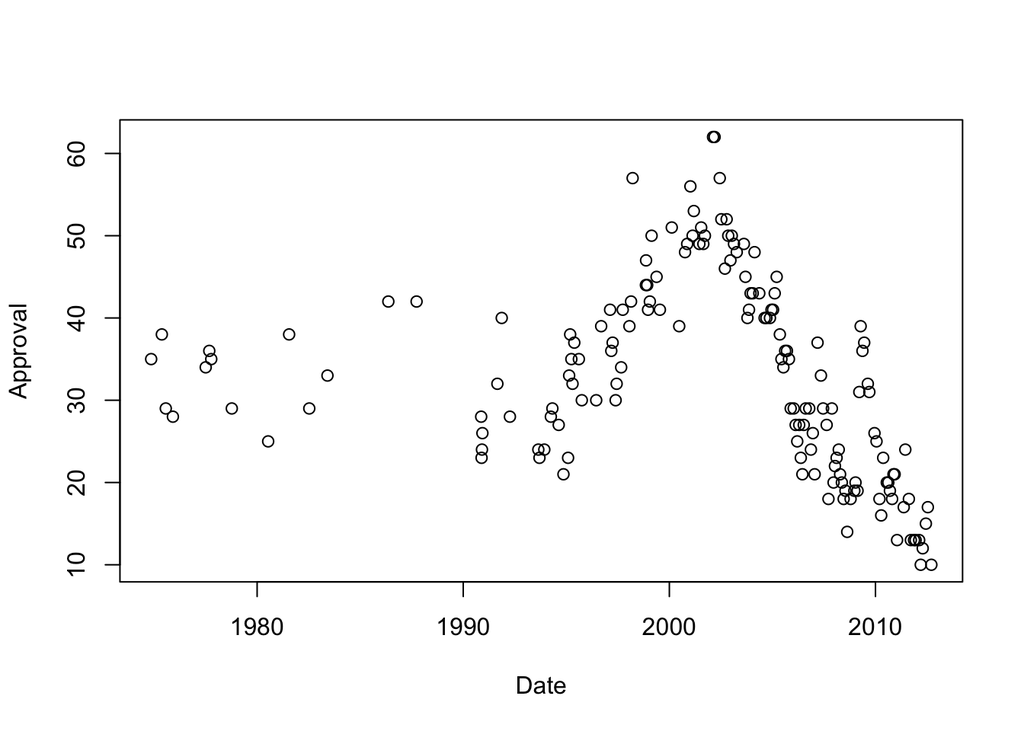

```r
plot(train.data[,2],train.data[,1],xlab="Date",ylab="Approval")
```

##### Write kNN reg funciton

```r
kNN.Regression <- function(x,data=data,k=5) {

  # Define distances
  D <- sqrt((x-data[,2])^2)

  # Find k-closest time points to x
  K.closest.ratings <- order(D)[1:k]

  # Return the mean of the k-corresponding response values (approval ratings)
  return(mean(data[K.closest.ratings,1]))

}
```

Choose K

```r
K <- 5
```

Plot training Data with and predicted values.

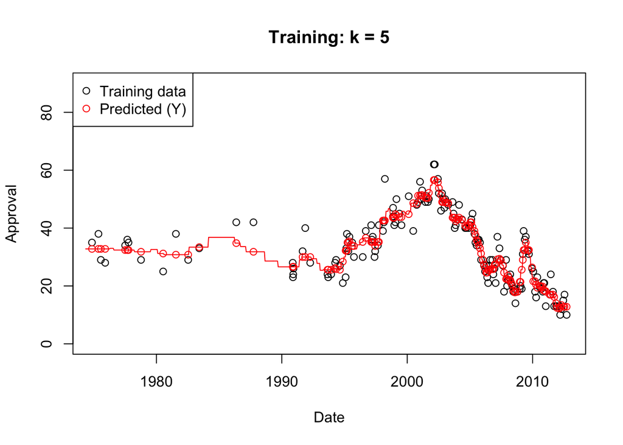

```r
plot(train.data[,2],train.data[,1],xlab="Date",ylab="Approval",main=paste("Training:","k =",K),ylim=c(0,90))
points(train.data[,2],sapply(train.data[,2],kNN.Regression,data=train.data,k=K),col=2)
x <- seq(from=min(data[,2]),to=max(data[,2]),by=.05)
lines(x,sapply(x,kNN.Regression,data=train.data,k=K),col="red")
legend("topleft",legend=c("Training data","Predicted (Y)"),col=c("Black","Red"),pch=c(1,1))
```

Plot test Data with and predicted values based on the trained model.

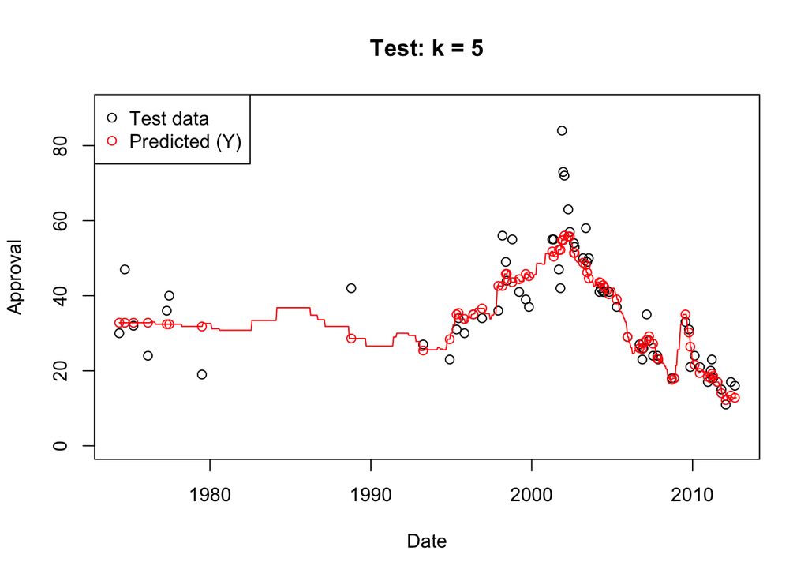

```r
plot(test.data[,2],test.data[,1],xlab="Date",ylab="Approval",main=paste("Test:","k =",K),ylim=c(0,90))
points(test.data[,2],sapply(test.data[,2],kNN.Regression,data=train.data,k=K),col=2)
x <- seq(from=min(data[,2]),to=max(data[,2]),by=.05)
lines(x,sapply(x,kNN.Regression,data=train.data,k=K),col="red")
legend("topleft",legend=c("Test data","Predicted (Y)"),col=c("Black","Red"),pch=c(1,1))
```

##### Compute MSE of the test data based on the model fit using the training data

```r
# Choose K
K=10
# Compute predicted Y based on training model
y.hat <- sapply(test.data[,2],kNN.Regression,data=train.data,k=K)

# Compute MSPE
y <- test.data[,1]
sum((y-y.hat)^2)/nrow(test.data)
```

```
## [1] 52.12329
```

Create a plot of test MSE and trained MSE

```r
MSPE <- NULL
MSE <- NULL
for (K in 1:20) {

  # Compute predicted Y based on training model
  y.hat.star <- sapply(test.data[,2],kNN.Regression,data=train.data,k=K)

  # Compute MSPE
  y.star <- test.data[,1]
  MSPE[K] <- sum((y.star-y.hat.star)^2)/nrow(test.data)


  y.hat <- sapply(train.data[,2],kNN.Regression,data=train.data,k=K)
  y <- train.data[,1]
  MSE[K] <- sum((y-y.hat)^2)/nrow(train.data)

}
```

First produce only test MSE

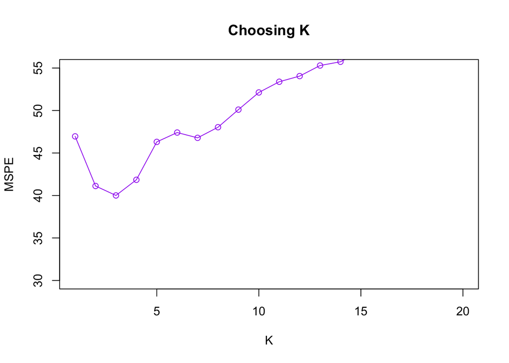

```r
plot(1:20,MSPE,xlab="K",type="l",main="Choosing K",ylim=c(30,55),col="purple")
points(1:20,MSPE,col="purple")
```

What is the best k?

```r
Best.K <- (1:20)[which(MSPE==min(MSPE))]
Best.K
```

```
## [1] 3
```

```r
min(MSPE)
```

```
## [1] 40.00476
```

Plot MSE and MSPE for different values of K.

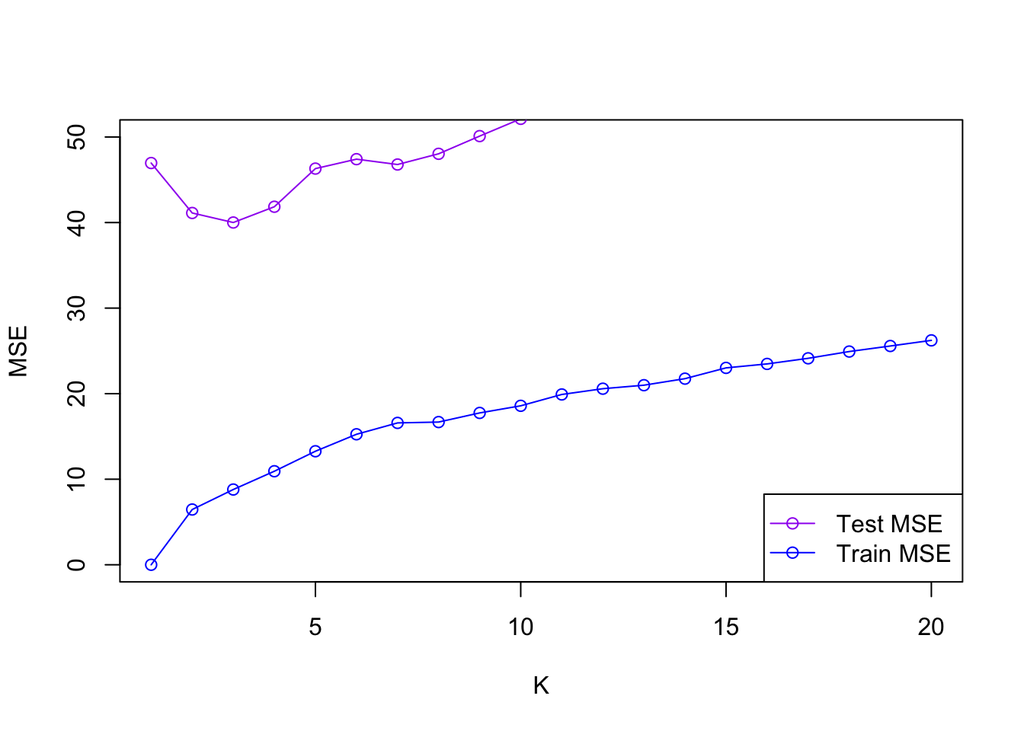

```r
plot(1:20,MSPE,xlab="K",type="l",ylab="MSE",main="",ylim=c(0,50),col="purple")
points(1:20,MSPE,col="purple")
lines(1:20,MSE,col="blue")
points(1:20,MSE,col="blue")
legend("bottomright",legend=c("Test MSE","Train MSE"),col=c("purple","blue"),pch=c(1,1),lty=c(1,1))
```

[^1]: **SMDA2**: Statistical Modeling and Data Analysis II course (Columbia University, Spring 2020, Cynthia Rush). **SML**: Statistical Machine Learning course (Columbia University, Spring 2020, Gabriel Young). **ESL**: Elements of Statistical Learning. **ISLR**: Introduction to Statistical Learning using R. **Duda**: Pattern Classification. **Bishop**: Pattern Recognition and Machine Learning. **Murphy**: Machine learning: a probabilistic perspective